# Tipos de materiales

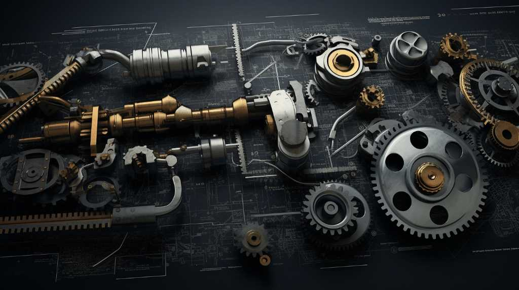

Fuente: discoverengineering.org

## Clasificación de los materiales

Los materiales que se usan en la industria se pueden agrupar en grandes **familias**:

- **Metales**
  - Ferrosos (con hierro como base).
  - No ferrosos (sin hierro o con muy poco hierro).
- **Cerámicos** (vidrios, porcelanas, ladrillos refractarios).
- **Polímeros** (plásticos, caucho).
- **Compuestos** (combinación de dos o más materiales, como fibra de vidrio y fibra de carbono).

En mecánica, los **metales** son los más utilizados por su resistencia y maquinabilidad.

**Versión en inglés**

The materials used in industry can be grouped into large **families**:

- **Metals**
  - Ferrous (iron-based).
  - Non-ferrous (little or no iron).
- **Ceramics** (glass, porcelain, refractory bricks).
- **Polymers** (plastics, rubber).
- **Composites** (combination of two or more materials, such as fiberglass and carbon fiber).

In mechanics, **metals** are the most widely used due to their strength and machinability.

## Aleaciones

Una **aleación** es la mezcla de dos o más elementos, donde al menos uno es metálico, para mejorar las propiedades.

Ejemplos:

- **Acero** = hierro + carbono (y a veces otros elementos como cromo, níquel, molibdeno).
- **Bronce** = cobre + estaño.
- **Latón** = cobre + zinc.

Las aleaciones permiten obtener materiales más resistentes, más duros, o más resistentes a la corrosión que los metales puros.

**Versión en inglés**

**2. Alloys** An **alloy** is the mixture of two or more elements, where at least one is metallic, to improve the properties.

Examples:

- **Steel** = iron + carbon (sometimes with other elements such as chromium, nickel, molybdenum).
- **Bronze** = copper + tin.
- **Brass** = copper + zinc.

Alloys make it possible to obtain materials that are stronger, harder, or more resistant to corrosion than pure metals.

## Metales ferrosos y no ferrosos

Los materiales ferrosos son materiales cuyo componente principal es el hierro. Se dividen en:

- **Hierro**: metal base, blando y poco resistente en estado puro, rara vez se usa solo.
- **Acero**: aleación de hierro y carbono (0,02–2%), puede endurecerse y templarse; muy usado en ejes, engranajes, herramientas.
- **Fundiciones**: aleaciones de hierro y carbono con más de 2% de C; fáciles de colar, resistentes a la compresión, empleadas en bloques de motor, bancadas de máquinas.

Comparación entre ferrosos y no ferrosos

- **Ferrosos**: hierro, acero, fundiciones.
  - Ventajas: resistentes, relativamente baratos.
  - Desventajas: pesados, se oxidan fácilmente.
- **No ferrosos**: cobre, aluminio, plomo, zinc, titanio, etc.
  - Ventajas: ligeros, buena conductividad, resisten a la corrosión.
  - Desventajas: suelen ser más costosos.

## Estructura cristalina y granular

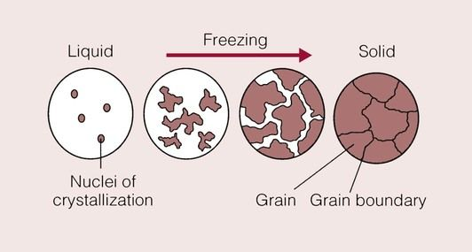

Al solidificarse, los átomos del metal se organizan en cristales que se agrupan formando granos. Fuente: pocketdentistry.com

Los metales sólidos no son homogéneos en toda su masa, sino que están formados por **cristales microscópicos** que se agrupan en regiones llamadas **granos**.

- **Cristales**: son arreglos ordenados de átomos (redes cristalinas) que se repiten en tres dimensiones.
- **Granos**: cada grano es un conjunto muy grande de celdas cristalinas con la misma orientación atómica. Al solidificar un metal, se forman muchos granos con diferentes orientaciones.
- **Límites de grano**: son las fronteras donde chocan dos orientaciones distintas. Estos límites influyen en la resistencia, la ductilidad y la dureza del material.

La **disposición de granos** puede observarse con un microscopio tras pulir y atacar químicamente la superficie del metal.

- Grano **fino** → mayor dureza y resistencia mecánica.
- Grano **grueso** → menor resistencia, más fragilidad.

Tratamientos térmicos como el **recocido, el temple y el revenido** permiten modificar el tamaño de los granos y, por lo tanto, las propiedades mecánicas del metal.

- **Recocido**: calentar y enfriar lentamente para ablandar el metal y refinar granos.
- **Temple**: calentar y enfriar bruscamente para endurecer.
- **Revenido**: recalentar después del temple y enfriar controlado para reducir fragilidad y dar tenacidad.

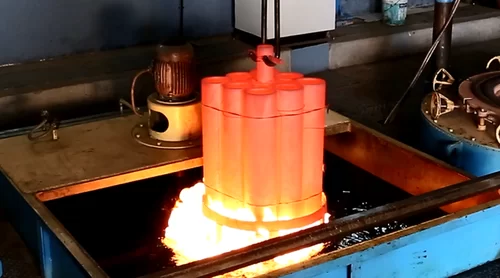

Temple con enfriamiento en aceite. Fuente: madearia.com

El conformado de piezas mediante golpes o presión también modifica los granos y las propiedades del metal. Un ejemplo es el laminado, donde la pieza pasa entre dos rodillos giratorios que la comprimen y le dan nueva forma.

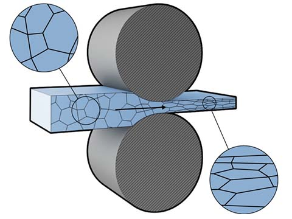

En el laminado los granos se alargan y la pieza aumenta su resistencia. Fuente: wzppgi.com

La estructura cristalina con granos no es exclusiva de los metales; también aparece en cerámicos y en algunos minerales y semiconductores que cristalizan. Lo particular de los metales es que sus granos cristalinos se pueden modificar fácilmente (conformado, tratamientos térmicos), lo que permite ajustar sus propiedades mecánicas.